# Fine-mapping and the missing regulation

Why PGC3 schizophrenia loci fail to colocalize with brain eQTLs — a quantitative dissection

Author

Connor Finnerty (analysis pipeline: github-tracked, fully regenerable from public downloads)

Published

August 11, 2026

## The question

Genome-wide significant schizophrenia loci overwhelmingly sit in non-coding sequence, yet they colocalize with brain expression QTLs far less often than a purely regulatory model predicts — the **“missing regulation”** puzzle. This report reproduces that observation on fully public data and quantitatively tests four competing explanations. Every number and figure regenerates from raw downloads via the project Snakefile; parameters live in `config/config.yaml`.

**Data**: PGC3 SCZ (Trubetskoy et al. 2022) primary autosome meta-analysis; 287 loci (Supplementary Table 3, SHA256-pinned) → 281 analysable (1 MHC, 5 chrX excluded). eQTLs: 13 GTEx v8 brain tissues + MetaBrain cortex-EUR (bulk), BrainSeq/ROSMAP/CommonMind DLPFC (power ladder), Walker 2019 fetal neocortex, Bryois 2022 sc-eQTLs (8 cell types). LD: 1000G GRCh38 EUR (n=503). All GRCh38, coloc 5.2.3 / susieR 0.14.2.

## Stage 1 — the gap replicates

|  | Dataset class | Colocalized (PP4>0.8) | Fraction | Wilson 95% CI |
| --- | --- | --- | --- | --- |
| 0 | GTEx cortex (N=205) | 27/281 | 10% | 7%–14% |
| 1 | MetaBrain cortex-EUR (N≈2,700) | 55/281 | 20% | 15%–25% |
| 2 | Any of 13 GTEx brain tissues | 67/281 | 24% | 19%–29% |
| 3 | Any of 14 bulk brain datasets | 90/281 | 32% | 27%–38% |

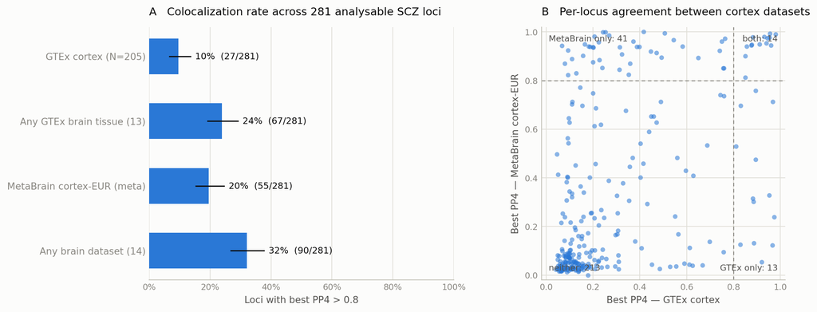

Positive controls anchor the pipeline: FURIN at 15-rs4702 (PP4 = 0.99996, MetaBrain) and ZNF823 at its two chr19 loci top the colocalization list. Of the 191 non-colocalizing loci, **180 (94%) contain at least one gene with a brain eQTL at p < 1e-6** in the ±1 Mb window — regulation is present but tags different variants.

## Stage 2 — four explanations, one ledger

|  | Step | Loci | Cumulative |
| --- | --- | --- | --- |
| 0 | Stage 1 bulk colocalization | 90 | 90 |
| 1 | (a) + multi-signal rescue (coloc-SuSiE) | 23 | 113 |
| 2 | (c) + single-cell-only colocalization | 6 | 119 |
| 3 | (d) + fetal-only colocalization | 4 | 123 |
| 4 | UNEXPLAINED | 158 | 281 |

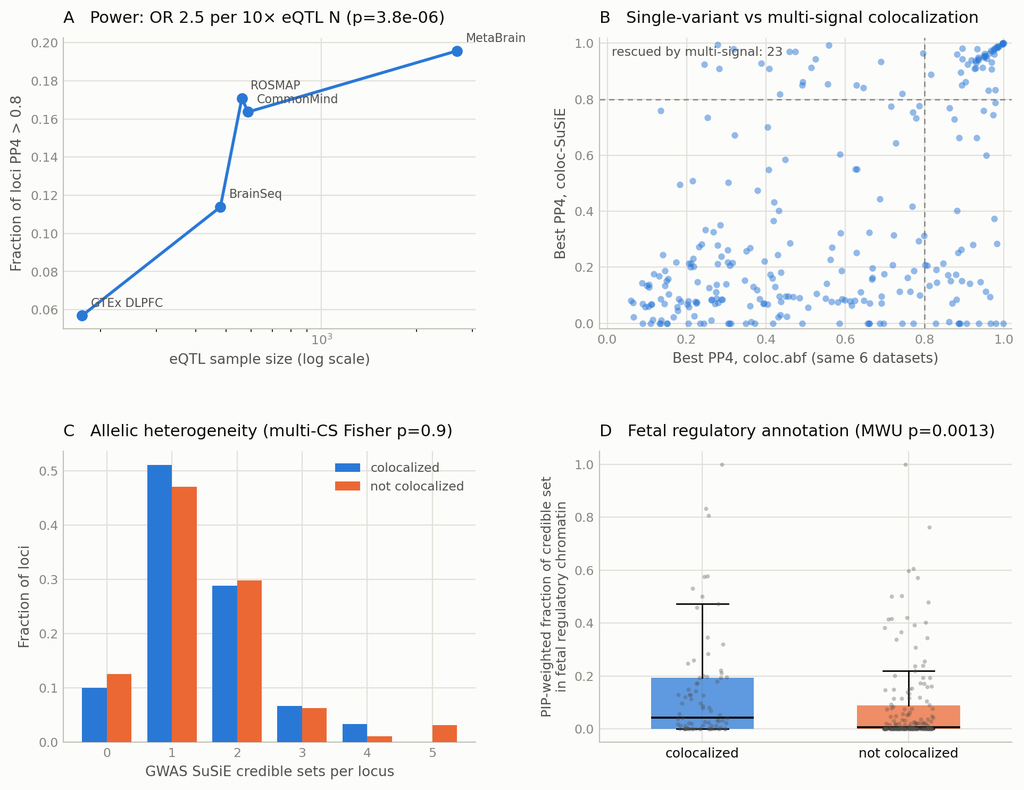

### (a) Allelic heterogeneity — reshapes more than it enlarges

|  | value |
| --- | --- |
| Loci with ≥2 GWAS credible sets | 112/281 |
| Multi-CS among misses vs hits | 40% vs 39% (Fisher p=0.90) |
| Rescued (miss→hit) | 23 |
| Demoted (hit→signals separate) | 23 of 85 abf hits |

Multi-signal architecture is common everywhere (~40% of loci) but **not enriched among misses** — heterogeneity is not the primary explanation for the gap. Its real effect is **churn**: 27% of single-variant coloc hits dissolve when signals are fine-mapped and paired individually (e.g. 22-rs9607782 × ENSG00000232710: abf PP4 = 0.97 → PP3 = 0.98, peaks ~30 kb apart), while a similar number of misses are rescued (e.g. 8-rs4129585: 0.56 → 0.99). Single-causal-variant colocalization misclassifies roughly a quarter of calls *in both directions*.

### (b) eQTL power — significant, saturating

|  | Dataset | eQTL N | Fraction colocalized | n |
| --- | --- | --- | --- | --- |
| 0 | QTD000176 | 175 | 6% | 16 |
| 1 | QTD000051 | 479 | 11% | 32 |
| 2 | QTD000434 | 560 | 17% | 48 |
| 3 | QTD000075 | 586 | 16% | 46 |
| 4 | MetaBrain_Cortex_EUR | 2683 | 20% | 55 |

Logistic OR = **2.5 per 10× eQTL sample size** (p = 3.8e-06), but the curve flattens: extrapolated bulk-cortex ceiling ≈ 25%. Power explains part of the gap; it cannot close it.

### (c) Cell-type dilution — small now, clearly under-sampled

|  | value |
| --- | --- |
| Loci colocalizing in ≥1 of 8 cell types (N=192!) | 37 |
| Missed by both bulk cortex datasets | 13 |
| Missed by all 14 bulk datasets | 6 |

Per donor, sc-eQTLs are strikingly productive (37 loci at N=192 vs 16 for bulk DLPFC at N=175); excitatory neurons dominate (23), then oligodendrocytes (12). Given the power curve in (b), this is the explanation most likely to grow.

### (d) Fetal / context specificity — weakest direct support, instructive twist

|  | value |
| --- | --- |
| Fetal-eQTL colocalizations (N=211) | 20 |
| …among Stage-1 misses | 5 |
| CS fetal-regulatory PIP, hits vs misses | 0.139 vs 0.085 (MWU p=0.001) |
| Fetal-not-adult enrichment | OR=0.99, p=1.00 |

Contrary to the fetal-enhancer hypothesis, non-colocalizing loci show *less* credible-set overlap with fetal regulatory chromatin than colocalizing loci — and the depletion is even stronger for adult chromatin (0.048 vs 0.136). The unexplained loci are not hiding in fetal enhancers; their credible sets sit in sequence **not annotated as regulatory in any surveyed brain context**.

## Threshold sensitivity

|  | PP4 threshold | GTEx cortex | MetaBrain | Any bulk brain | coloc-SuSiE (6 ds) | Any Bryois cell type |
| --- | --- | --- | --- | --- | --- | --- |
| 0 | 0.5 | 53 | 81 | 151 | 89 | 100 |
| 1 | 0.7 | 35 | 64 | 111 | 76 | 59 |
| 2 | 0.8 | 27 | 55 | 90 | 65 | 37 |
| 3 | 0.9 | 13 | 40 | 62 | 52 | 19 |

## Ranked verdict

1. **eQTL power** — strongest statistical signal, bounded upside (~25% ceiling).
2. **Single-variant-assumption error** (allelic heterogeneity) — corrects ~26% of classifications in both directions; a methods lesson more than a gap-closer.
3. **Cell-type dilution** — small measured contribution, largest growth potential.
4. **Fetal-specific regulation** — minimal direct contribution; chromatin evidence redirects the hypothesis toward contexts *not yet assayed*.

## Best candidates for context-specific regulation

Top 20 unexplained-or-borderline loci ranked by `context_score` (sc/fetal coloc evidence + fetal-skewed credible-set chromatin):

| locus_id | index SNP | GWAS credible sets | best sc PP4 | best cell type | fetal PP4 | CS fetal-reg PIP | CS adult-reg PIP | score |
| --- | --- | --- | --- | --- | --- | --- | --- | --- |
| 8-rs4129585 | rs4129585 | 2 | 0.906 | Bryois_Astrocytes | 0.229 | 0.160 | 0.009 | 3.150 |
| 6-rs9390083 | rs9390083 | 1 | 0.197 | Bryois_Inhibitory_neurons | 0.860 | 0.115 | 0.000 | 3.115 |
| 2-rs12471454 | rs12471454 | 3 | 0.889 | Bryois_Inhibitory_neurons | 0.549 | 0.076 | 0.021 | 3.055 |
| 2-rs11680723 | rs11680723 | 5 | 0.866 | Bryois_Inhibitory_neurons | 0.506 | 0.042 | 0.046 | 3.000 |
| 7-rs2057884 | rs2057884 | 1 | 0.852 | Bryois_Oligodendrocytes | 0.164 | 0.022 | 0.037 | 3.000 |
| 17-rs959071 | rs959071 | 3 | 0.569 | Bryois_Astrocytes | 0.946 | 0.174 | 0.361 | 3.000 |
| 6-rs9470670 | rs9470670 | 2 | 0.194 | Bryois_Astrocytes | 0.894 | 0.029 | 0.035 | 3.000 |
| 16-rs12925872 | rs12925872 | 1 | 0.322 | Bryois_Inhibitory_neurons | 0.922 | 0.000 | 0.000 | 2.000 |
| 10-rs7900775 | rs7900775 | 0 | 0.815 | Bryois_Excitatory_neurons | 0.104 | NaN | NaN | 2.000 |
| 5-rs252812 | rs252812 | 1 | 0.824 | Bryois_Excitatory_neurons | 0.098 | 0.000 | 0.000 | 2.000 |
| 5-rs72723227 | rs72723227 | 1 | 0.811 | Bryois_Inhibitory_neurons | 0.199 | 0.000 | 0.000 | 2.000 |
| 12-rs1463209 | rs1463209 | 0 | 0.818 | Bryois_Excitatory_neurons | 0.078 | NaN | NaN | 2.000 |
| 17-rs3909258 | rs3909258 | 2 | 0.584 | Bryois_Astrocytes | 0.957 | 0.238 | 0.534 | 2.000 |
| 2-rs12991836 | rs12991836 | 1 | 0.642 | Bryois_Excitatory_neurons | 0.097 | 0.762 | 0.000 | 1.762 |
| 12-rs10777341 | rs10777341 | 1 | 0.299 | Bryois_Excitatory_neurons | 0.107 | 0.606 | 0.000 | 1.606 |
| 9-rs10781248 | rs10781248 | 1 | 0.224 | Bryois_Microglia | 0.055 | 0.479 | 0.000 | 1.479 |
| 3-rs167924 | rs167924 | 1 | 0.163 | Bryois_Astrocytes | 0.105 | 0.403 | 0.011 | 1.392 |
| 1-rs56335113 | rs56335113 | 2 | 0.517 | Bryois_Excitatory_neurons | 0.362 | 0.392 | 0.004 | 1.388 |
| 2-rs7604885 | rs7604885 | 1 | 0.239 | Bryois_Inhibitory_neurons | 0.173 | 0.383 | 0.000 | 1.383 |
| 1-rs41314284 | rs41314284 | 1 | 0.251 | Bryois_Astrocytes | 0.137 | 0.366 | 0.000 | 1.366 |

## Extension: splicing, methylation, and robustness

|  | Channel | Newly explained | Total hits (PP4>0.8) |
| --- | --- | --- | --- |
| 0 | bulk_expression | 90 | 90 |
| 1 | susie_rescue | 23 | 23 |
| 2 | single_cell | 6 | 37 |
| 3 | fetal_eqtl | 4 | 20 |
| 4 | splicing | 9 | 47 |
| 5 | methylation | 84 | 193 |
| 6 | UNEXPLAINED | 65 |  |

Extending the ledger to two further molecular layers changes the verdict qualitatively. **Splicing** (17 brain sQTL datasets): 47 loci colocalize, 9 of them surviving every prior channel. **Methylation** (Brain-mMeta, ~1,160 brains): **193/281 loci share a causal variant with a brain CpG, including 118 of the 191 expression-orphan loci** — collapsing the unexplained core from 57% to **23% (65 loci)**. This is not a trait-multiplicity artifact: per-test colocalization runs ~6× higher for methylation than expression (1.2% vs 0.2%) at comparable test counts per locus, and 68 expression-misses persist even at PP4 > 0.95.

Interpretation: most “missing regulation” loci are demonstrably **epigenetically active in adult brain** — the shared causal variant moves DNA methylation — while the transcriptional consequence stays invisible to every surveyed eQTL context. Colocalization is mechanism-symmetric (methylation need not mediate risk), but combined with the credible-set chromatin depletion, the coherent reading is regulation whose expression effects are context-, state-, or timing-restricted, or buffered at steady state.

Robustness: EUR-only GWAS reruns agree with the primary analysis at 94–96% of classifications (Spearman PP4 ≈ 0.89); LD-mismatch diagnostics (kriging_rss) show a median 2% outlier fraction with no locus above 5%; fetal-mQTL overlap is *depleted* among expression misses (OR 0.30, p = 6e-4), echoing the chromatin-depletion result.

Finally, a **transitive CpG→gene chain** (GWAS↔︎CpG PP4 × CpG↔︎MetaBrain- expression PP4) nominates target genes for the methylation-explained loci: 101 loci carry high-tier nominations (median 2 genes), including **44 expression-orphan loci** whose median direct expression PP4 was only 0.24 — sub-threshold eQTL support elevated to gene-level candidacy by the methylation route (`results/final/gene_nominations.tsv`; anchors include ZBED4, ANKK1, HYKK, LY6H).

## Reproducibility

`git clone` → `conda env create -f envs/scz-coloc.yml` → `snakemake -s workflow/Snakefile all results/stage2/explanations.tsv results/stage2/fig_stage2.png --cores N --resources net=8` → `quarto render report/report.qmd`. Raw-data provenance (URLs, sizes, SHA256s) recorded in sidecar files at download time; the supplementary-table zip is checksum-pinned in config.